# 14 Inital survival Analysis

Katie M Susong

03-June-22

# Overview

Inital plots and correlation for survival/hatch rate.

## Plots and Analysis

1. histogram of percent survival - the distribution is skewed to 0, given bounding at 0 and 1 pdf = beta
2. GDDs
   1. Plots
      1. histogram
      2. correlation scatter plots
   2. Correlation tests : all measures so some correlation
   3. Regression
      1. null model: per.sur.live ~ 1
      2. GDDdjf10
      3. GDDfull10
      4. GDDdjf -12
      5. GDDfull -12
3. Mean Jan T

```r
rm (list  = ls())
#libraries#
library(dplyr)
library(ggplot2)
library(betareg)
library(sjPlot)
library(patchwork)

#### Functions ####
overdisp_fun <- function(model) {
  rdf <- df.residual(model)
  rp <- residuals(model,type="pearson")
  Pearson.chisq <- sum(rp^2)
  prat <- Pearson.chisq/rdf
  pval <- pchisq(Pearson.chisq, df=rdf, lower.tail=FALSE)
  c(chisq=Pearson.chisq,ratio=prat,rdf=rdf,p=pval)
}


#### Import data ####
setwd("~/Documents/CBS_PhD/Ae.albo_OW_2021/21.22_Ae.albopictus_Overwintering")
# import data avg. to the tire level
tire <- read.csv("00_Data/21.22_bytire.hatch_temperature_summary_NO.Arl3.csv")
# format corrections
tire <- subset(tire, select = -c(X))
tire$site    <- factor(tire$site, levels = c("", "Car", "Bon", "Dek", "Arl", "Han", "Spo"))
tire$loc.id <- factor(tire$loc.id, levels = c("CTR",
                                              "IL_Car_T1", "IL_Car_T2",
                                              "IL_Bon_T1", "IL_Bon_T2",
                                              "IL_Dek_T1", "IL_Dek_T2",
                                              "WI_Arl_T1", "WI_Arl_T2",
                                              "WI_Han_T1", "WI_Han_T2",
                                              "WI_Spo_T1" ,"WI_Spo_T2"))

# import data avg. to the site
site <- read.csv("00_Data/21.22_bysite.hatch_temperature_summary_NO.Arl3.csv")
# format
site$site    <- factor(site$site, levels = c("CTR", "Car", "Bon", "Dek", "Arl", "Han", "Spo"))
site <- subset(site, select = -c(X))

# filter control out of df
site_n <- site %>%
  filter( site != "CTR")
tire_n <- tire %>%
  filter( loc.id != "CTR")
```

### 2. GDDs v survival

#### b.Correlation tests

```r
# Pearson correlation test for each GDDs metric
cor.test(tire$per.sur.live, tire$GDD_10_DJF, method = "pearson")
cor.test(tire$per.sur.live, tire$GDD_n12_DJF, method = "pearson")
cor.test(tire$per.sur.live, tire$GDD_10_FULL, method = "pearson")
cor.test(tire$per.sur.live, tire$GDD_n12_FULL, method = "pearson")
```

[output not shown]

#### c. Regression

```r
# return to 2,2 plots of model test plots
par(mfrow=c(2,2))
```

**Null Model**

```r
# null model
null <- glm(per.sur.live ~ 1, data = tire)
summary(null)
```

[output not shown]

**GDD (set to temperatures => 10 ºC) during DJF**

```r
GDDdjf10 <- glm(per.sur.live ~ GDD_10_DJF, data = tire) # GDD (djf 10ºC)
summary(GDDdjf10)
# measures of fitness
plot(GDDdjf10)          # fitness plots
overdisp_fun(GDDdjf10)  # overdisp. function
```

[output not shown]

**GDD (set to temperatures => 10 ??C) during full time**

```r
GDDfull10 <- glm(per.sur.live ~ GDD_10_FULL, data = tire) # GDD (full 10C)
summary(GDDfull10)
```

```
Call:
glm(formula = per.sur.live ~ GDD_10_FULL, data = tire)

Deviance Residuals:
     Min        1Q    Median        3Q       Max
-0.16889  -0.08257  -0.03359   0.03649   0.28459

Coefficients:
              Estimate Std. Error t value Pr(>|t|)
(Intercept) -0.1128371  0.0792269  -1.424  0.18483
GDD_10_FULL  0.0011270  0.0003042   3.704  0.00408 **
---
Signif. codes:  0 ‘***’ 0.001 ‘**’ 0.01 ‘*’ 0.05 ‘.’ 0.1 ‘ ’ 1

(Dispersion parameter for gaussian family taken to be 0.02273462)

    Null deviance: 0.53934  on 11  degrees of freedom
Residual deviance: 0.22735  on 10  degrees of freedom
  (1 observation deleted due to missingness)
AIC: -7.5397

Number of Fisher Scoring iterations: 2
```

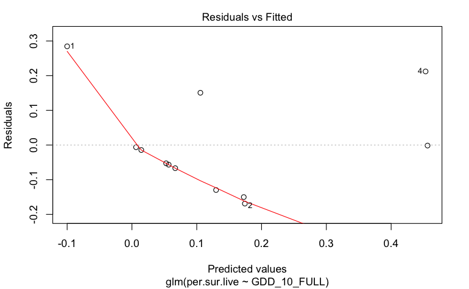

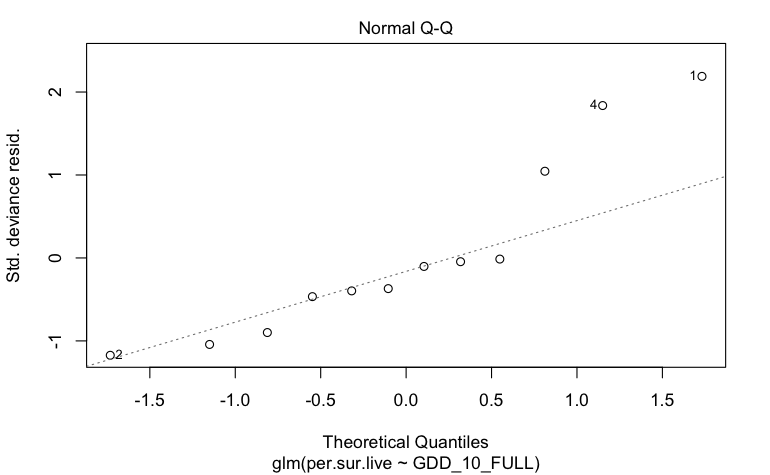

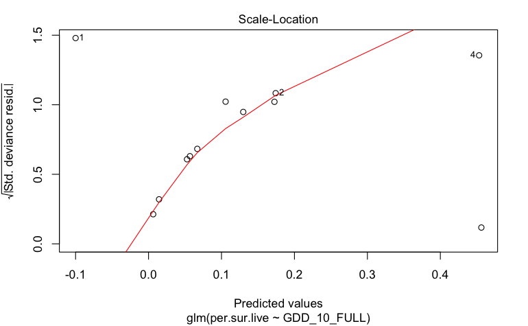

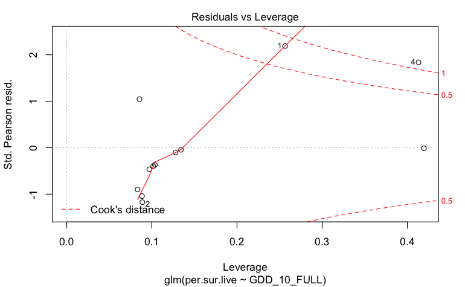

```r
plot(GDDfull10)
```

```r
overdisp_fun(GDDfull10)
```

```
      chisq       ratio         rdf           p
 0.22734619  0.02273462 10.00000000  0.99999986
```

MODEL FITNESS

- Residuals vs Fitted: Some change in variance of residuals. Trend of residuals is noted
- Normal Q-Q: 1.0 + Theo. Quantiles are not linear
- Scale-Location: strong pattern in residuals
- Residual vs Leverage: obs. 1 and 4 have strong leverage
- over dispersal: is not significantly overdisp.

**GDD (set to temperatures => -12 C) during DJF time**

```r
# GDD (full 10??C)
GDDdjfn12 <- glm(per.sur.live ~ GDD_n12_DJF, data = tire)
summary(GDDdjfn12)
```

```
Call:
glm(formula = per.sur.live ~ GDD_n12_DJF, data = tire)

Deviance Residuals:
     Min        1Q    Median        3Q       Max
-0.10772  -0.08577  -0.03167   0.02564   0.19905

Coefficients:
              Estimate Std. Error t value Pr(>|t|)
(Intercept) -1.022e+01  1.846e+00  -5.536 0.000249 ***
GDD_n12_DJF  5.168e-03  9.213e-04   5.609 0.000225 ***
---
Signif. codes:  0 ‘***’ 0.001 ‘**’ 0.01 ‘*’ 0.05 ‘.’ 0.1 ‘ ’ 1

(Dispersion parameter for gaussian family taken to be 0.01300895)

    Null deviance: 0.53934  on 11  degrees of freedom
Residual deviance: 0.13009  on 10  degrees of freedom
  (1 observation deleted due to missingness)
AIC: -14.239

Number of Fisher Scoring iterations: 2
```

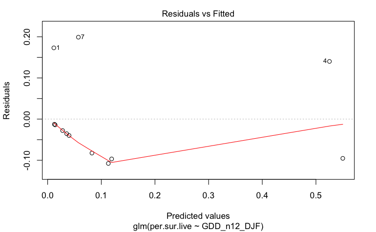

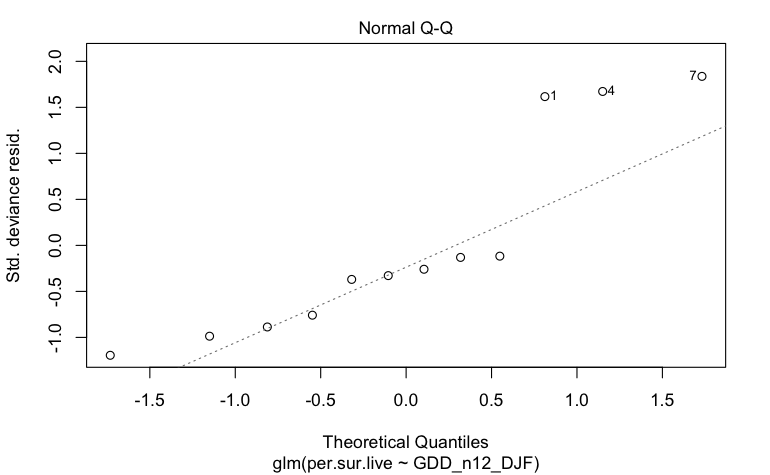

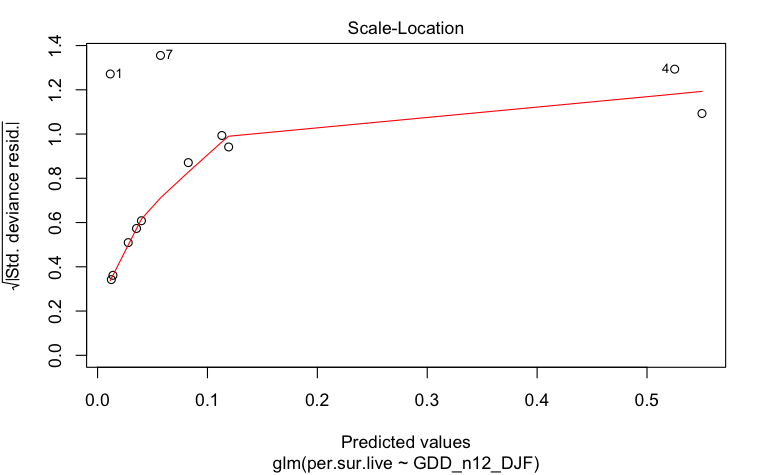

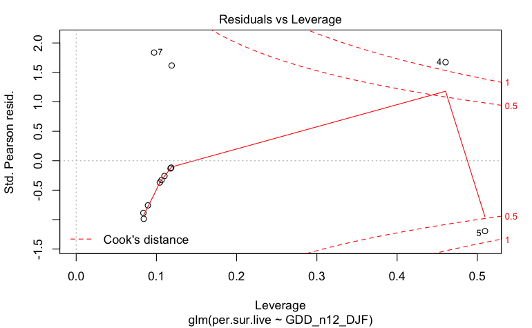

```r
plot(GDDdjfn12)
```

```r
overdisp_fun(GDDdjfn12)
```

```
      chisq       ratio         rdf           p
 0.13008945  0.01300895 10.00000000  0.99999999
```

MODEL FITNESS

- Residuals vs Fitted: limited heteroscedasticity
- Normal Q-Q: 1.0 + Theo. Quantiles are not linear
- Scale-Location: mild trend in small predicted values
- Residual vs Leverage: obs. 4 and 5 have strong leverage
- over dispersal: is not overdisp.

**GDD (set to temperatures => -12 C) during Full time**

```r
# GDD (full 10??C)
GDDfulln12 <- glm(per.sur.live ~ GDD_n12_FULL, data = tire)
summary(GDDfulln12)
```

```
Call:
glm(formula = per.sur.live ~ GDD_n12_FULL, data = tire)

Deviance Residuals:
     Min        1Q    Median        3Q       Max
-0.16889  -0.08257  -0.03359   0.03649   0.28459

Coefficients:
               Estimate Std. Error t value Pr(>|t|)
(Intercept)  -4.8660469  1.3499922  -3.604  0.00481 **
GDD_n12_FULL  0.0011270  0.0003042   3.704  0.00408 **
---
Signif. codes:  0 ‘***’ 0.001 ‘**’ 0.01 ‘*’ 0.05 ‘.’ 0.1 ‘ ’ 1

(Dispersion parameter for gaussian family taken to be 0.02273462)

    Null deviance: 0.53934  on 11  degrees of freedom
Residual deviance: 0.22735  on 10  degrees of freedom
  (1 observation deleted due to missingness)
AIC: -7.5397

Number of Fisher Scoring iterations: 2
```

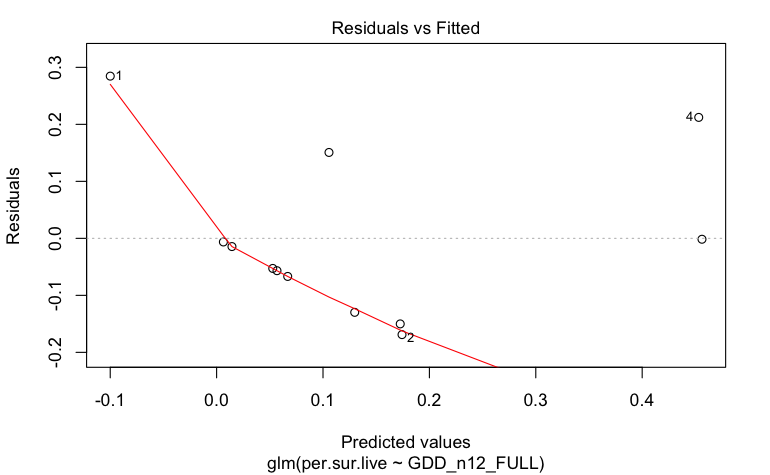

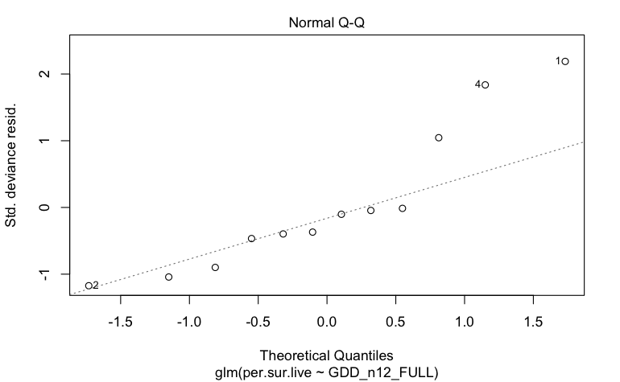

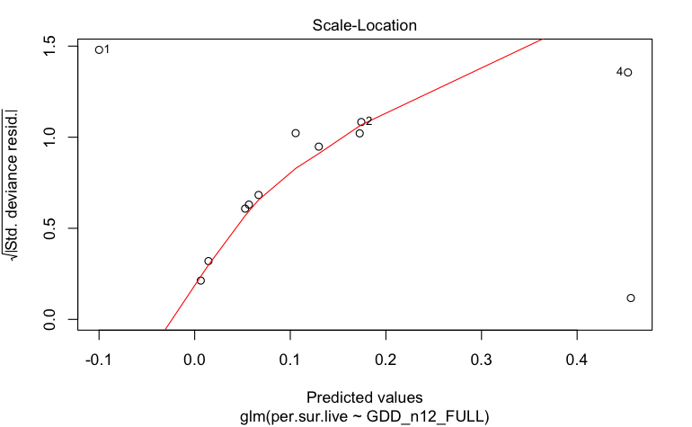

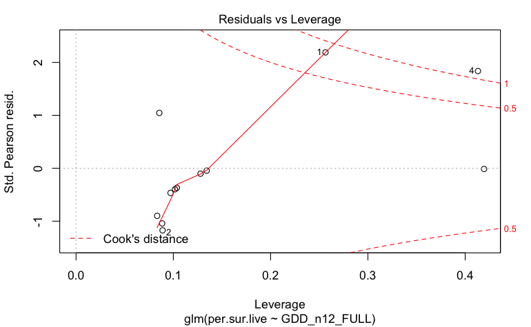

```r
plot(GDDfulln12)
```

```r
overdisp_fun(GDDfulln12)
```

```
      chisq       ratio         rdf           p
 0.22734619  0.02273462 10.00000000  0.99999986
```

MODEL FITNESS

- Residuals vs Fitted: trend in variance, possible heteroscad.
- Normal Q-Q: 1.0 + Theo. Quantiles are not linear
- Scale-Location: strong trend
- Residual vs Leverage: obs. 1 and 4 have strong leverage
- over dispersal: in not overdisp.

### 3. Survival v Mean Jan tire temperature

#### a. Plots

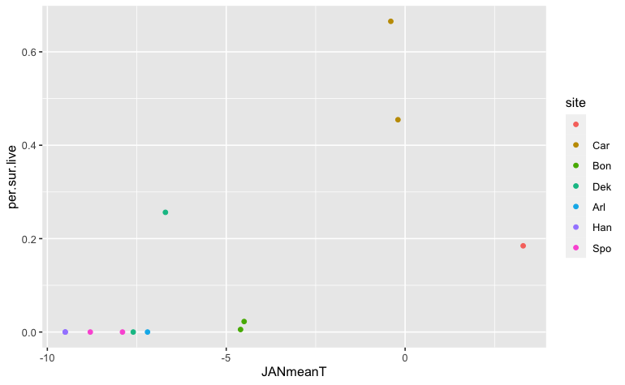

```r
ggplot(tire, aes(JANmeanT, per.sur.live, col = site))+
  geom_point()
```

#### b. Correlation test

CORRELATION TEST NOTES:

- Survival is strongly correlated to the internal tire temperature. Corr = 0.8269 (p=0.001)

```r
# Pearson correlation test
cor.test(tire_n$per.sur.live, tire_n$JANmeanT, method = "pearson")
```

[output not shown]

#### c. Regression

```r
reg.JanMeanT <- glm(per.sur.live ~ JANmeanT, data = tire_n)
# summary
summary(reg.JanMeanT)
```

```
Call:
glm(formula = per.sur.live ~ JANmeanT, data = tire_n)

Deviance Residuals:
     Min        1Q    Median        3Q       Max
-0.20800  -0.05139  -0.01331   0.07011   0.20897

Coefficients:
            Estimate Std. Error t value Pr(>|t|)
(Intercept)  0.47951    0.08986   5.337 0.000471 ***
JANmeanT     0.05785    0.01311   4.412 0.001691 **
---
Signif. codes:  0 ‘***’ 0.001 ‘**’ 0.01 ‘*’ 0.05 ‘.’ 0.1 ‘ ’ 1

(Dispersion parameter for gaussian family taken to be 0.01884369)

    Null deviance: 0.53637  on 10  degrees of freedom
Residual deviance: 0.16959  on  9  degrees of freedom
  (1 observation deleted due to missingness)
AIC: -8.6781

Number of Fisher Scoring iterations: 2
```

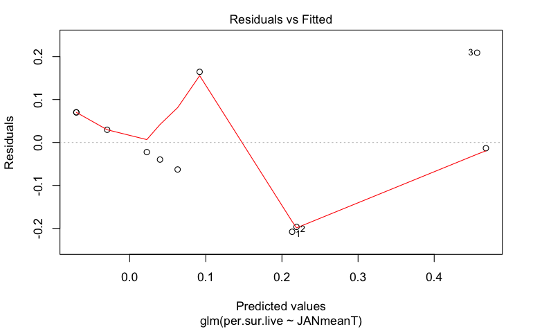

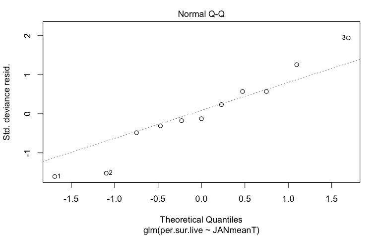

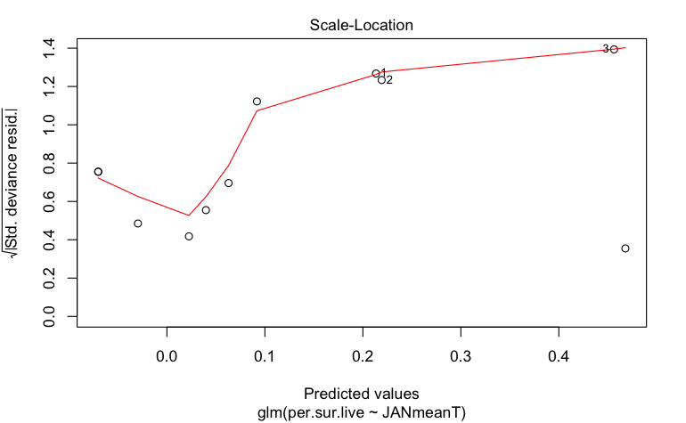

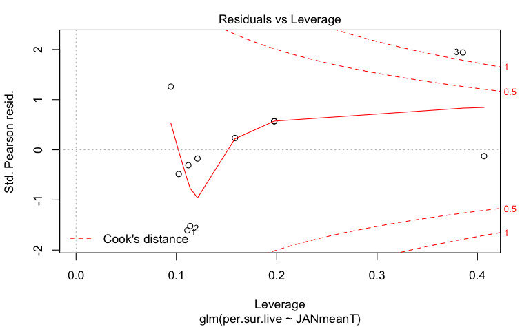

```r
plot(reg.JanMeanT)
```

```r
overdisp_fun(reg.JanMeanT)
```

```
     chisq      ratio        rdf          p
0.16959318 0.01884369 9.00000000 0.99999973
```

MODEL FITNESS

- Residuals vs Fitted: generally even distribution
- Normal Q-Q: generally linear
- Scale-Location: some pattern in the residuals, generally horizontal
- Residual vs Leverage: Obs. 3 is influential
- over dispersal: Not significantly overdisp.

### 4. Survival v DaysB12T

```r
ggplot(tire, aes(DaysB12T, per.sur.live, col = site))+
  geom_point()
```

[output not shown]

5. Survival v hrB12Tcon

```r
ggplot(tire, aes(MAXHrsB12conT, per.sur.live, col = site))+
  geom_point()
```

[output not shown]